# PaCE Patterns of Conflict Emergence

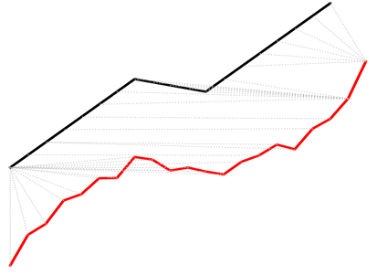

# What is PaCE?

PaCE is an ERC-funded project that aims to uncover recurring temporal sequences in the run-up to war.

The idea that history may repeat itself is old. But are there really recurring patterns in the escalation and emergence of wars? Just as DNA sequencing has been critical to medical diagnoses, PaCE aims to diagnose international politics by uncovering the relevant patterns in the area of conflict.

Recent advances overcoming methodological and data barriers present an opportunity to identify these recurrences empirically and to examine whether these patterns can be classified to improve forecasts and inform theories of conflict. I propose to combine new methods using the shape of the sequence of events rather than its raw values—and novel data on conflict from finance, diplomatic cables, and newspapers, to extract typical pre-war motifs.

# Objectives

### Identify patterns

Identify patterns in the pre-conflict actions using data on conflict events—from the onset of WWI to Hamas’s rocket launches—and in their perceptions using data from financial markets (the “crowd’s” perception), news articles (the “experts”), and diplomatic documents (the policy-makers). This will allow us to evaluate the patterns of escalation over different timescales—from the decade to the minute. The similarity between temporal sequences will be measured using algorithms which allow for flexible matching, such as Dynamic Time Warping.

### Forecast

Evaluate the utility of these patterns to improve forecasts of conflict with both historical and live out-of-sample predictions. Our results, using shape-based classification methods, will be made public and evaluated in real time. Moreover, using new measures of complexity to distinguish regular, chaotic, and random behavior, I will measure possible fundamental limits to the predictability of conflict events.

### Theory

Summarize the core features of dangerous patterns into motifs—recurring patterns—that can help build new theories of conflict emergence and escalation. PaCE will build a repository of shapes—a grammar of patterns—to be used as the building blocks of new theories.

# Funding

PaCE is funded by ERC grant 101002240 and is hosted at the Department of Political Science at Trinity College Dublin.

[figure not shown]

[figure not shown]

# PaCE is hiring!

Available [open positions in PaCE](http://www.conflictpatterns.com/openPositions)